# Multilevel models

GDR Vision - Paris 4/10/2018

## Today's program

1. Multilevel models from a frequentist perspective
2. The Bayesian approach
3. Markov Chain Monte Carlo (MCMC)
4. Examples

## Linear models

- The dependent variable \(y\) is modeled as a weighted combination of the independent variables, plus an additive error \(\epsilon\) \[ y_i=\beta_0 + \beta_1x_{1i} + \ldots +\beta_nx_{ni} + \epsilon_i \\ \epsilon \sim \mathcal{N}\left( 0, \sigma^2 \right) \]

## Linear models

- The dependent variable \(y\) is modeled as a weighted combination of the independent variables, plus an additive error \(\epsilon\) \[ \textbf{Y} = \textbf{X}\beta + \epsilon \\ \epsilon \sim \mathcal{N}\left( 0, \sigma^2 \right) \]

Matrix notation:

\[ \bf{Y} = \bf{X}\beta + \epsilon \] \[ \left( \begin{array}{c} y_1 \\ \vdots \\ y_m \end{array} \right) = \left( \begin{array}{cccc} 1 & x_{11} & \ldots & x_{1n}\\ \vdots & \vdots & \vdots & \vdots\\ 1 & x_{m1} & \ldots & x_{mn} \end{array} \right) \left( \begin{array}{c} \beta_0 \\ \beta_1 \\ \vdots \\ \beta_n \end{array} \right) + \left( \begin{array}{c} \epsilon_1 \\ \vdots \\ \epsilon_m \end{array} \right) \]

Matrix multiplication: \[ \left( \begin{array}{cc} a & b \\ c& d \end{array} \right) \left( \begin{array}{c} 1 \\ 2 \end{array} \right) = 1 \left( \begin{array}{c} a \\ c \end{array} \right) + 2 \left( \begin{array}{c} b \\ d \end{array} \right) = \left( \begin{array}{c} a + 2b \\ c+ 2d \end{array} \right) \]

## Linear mixed-effects models

- 'Classical' linear models are *fixed-effects* only:
  - independent variables are all experimental manipulation (they are not random).
  - the only random source of variation is the residual error \(\epsilon \sim \mathcal{N}\left( 0, \sigma^2 \right)\).
- However *observations* (e.g. trials) are often grouped according to *observational cluster* (e.g. subjects), random samples from a larger population, on which we'd like to make inferences.
- In order to properly generalize from the sample to the population, these variables should be treated as *random effects*. Mixed-effects models allow to do that by explicitly modelling the population distribution.
- A model containing both fixed and random effects is usually called a *mixed-effects* model (but also: hierarchical, multilevel, etc.).
- Random effects are treated as random variations around a population mean. These random variations are usually assumed to have a Gaussian distribution.
- A simple example: a *random-intercept* model. Regressions have the same slope in each of the \(J\) groups (\(j=1,\dots,J\)), but random variations in intercept \[ y_{ij} = \beta_0 + b_j + \beta_1x_{ij} + \epsilon_{i}\\ \epsilon \sim \mathcal{N}\left( 0, \sigma^2 \right)\\ b \sim \mathcal{N}\left( 0, \sigma_b^2 \right) \]
- General formulation in matrix notation \[ \textbf{Y} = \textbf{X}\beta + \textbf{Z}b + \epsilon \] where \(\textbf{X}\) and \(\textbf{Z}\) are the known fixed-effects and random-effects regressor matrices.
- The components of the residual error vector \(\epsilon \sim \mathcal{N}\left( 0, \sigma^2 \right)\) are assumed to be *i.i.d.* (independent and identically distributed).
- The random-effect components, \(b \sim \mathcal{N}\left( 0, \Omega \right)\) are assumed to be normally distributed with mean 0, however they are not necessarily independent (the components \(b_j\) can be correlated, and correlations can be estimated). Example:\[ \left[ {\begin{array}{c} {{b_0}}\\ {{b_1}} \end{array}} \right] \sim\cal N \left( {\left[ {\begin{array}{c} 0 \\ 0 \end{array}} \right],\Omega = \left[ {\begin{array}{c} {{\mathop{\rm Var}} \left( b_0 \right)} & {{\mathop{\rm cov}} \left( {{b_0},{b_1}} \right)}\\ {{\mathop{\rm cov}} \left( {{b_0},{b_1}} \right)} & {{\mathop{\rm Var}} \left( b_1 \right)} \end{array}} \right]} \right) \]

## Likelihood function

- Parameters (\(\beta\), \(\sigma^2\) and \(\Omega\)) are estimated by maximizing the likelihood function, which is the probability of the data, given the parameters (but treated as a function of the parameters, keeping the data fixed).
- The probability of the data *conditional to the random effects* is integrated with respect to the marginal density of the random effects, to obtain the marginal density of the data \[ L\left(\beta,\sigma^2,\Omega \mid \text{data}\right) = \int p \left(\text{data} \mid \beta,\sigma^2, b\right) \, p\left(b \mid \Omega\right) \, db \]

## ML vs REML

- The \(\textsf{R}\) library `lme4` provides two methods for estimating parameters: Maximum Likelihood (ML) and Restricted Maximum Likelihood (REML).
- ML tend to be biased and underestimate the variance components (e.g. \(\Omega\)).
- REML provide less biased variance estimates: conceptually can be seen as similar to Bessel's correction for sample variance (using \(n-1\) instead of \(n\) in the denominator).

## Advantages of multilevel models

- Improved estimates for *repeated sampling* (e.g. repeated-measures design).
- Improved estimates for *imbalances in sampling* (e.g. unequal number of trials across subjects).
- Avoid averaging (pre-averaging of data remove variation and can manifacture false confidence).
- Subject-specific standard error is taken into account in group-level estimates.
- Variation among group or individuals is modelled explicitly.
- Outperform classical methods in predictive ability.

## Example 1 `sleepstudy`

`sleepstudy` is a dataset in the `lme4` package, with reaction times data from 18 subjects that were restricted to 3 hours of sleep for 10 days.

Questions:

- how reaction times changes with each sleep-deprived night?
- are individual difference in baseline response times related to individual differences in the effect of sleep deprivation?

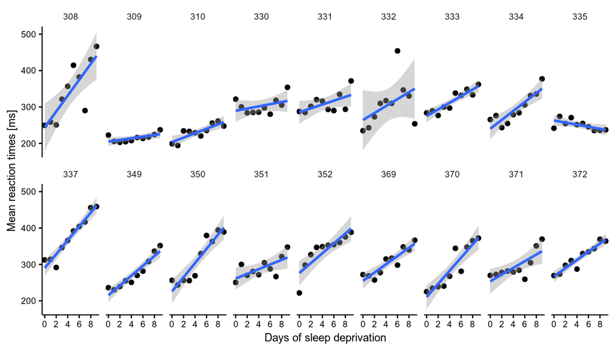

```r
str(sleepstudy)
'data.frame':   180 obs. of  3 variables:
 $ Reaction: num  250 259 251 321 357 ...
 $ Days    : num  0 1 2 3 4 5 6 7 8 9 ...
 $ Subject : Factor w/ 18 levels "308","309","310",..: 1 1 1 1 1 1 1 1 1 1 ...
```

- The model we want to fit includes both random slopes and intercept \[ y_{ij} = \beta_0 + b_{0j} + \left( \beta_1 + b_{1j} \right) \times {\rm{Days}}_i + \epsilon_i \\ \epsilon \sim \mathcal{N}\left( 0, \sigma^2 \right) \\ b\sim\cal N \left( 0, \Omega\right) \]
- In `lme4`

```r
m.1 <- lmer(Reaction ~ 1 + Days + (1 + Days | Subject),
    sleepstudy)
```

```r
summary(m.1)
Linear mixed model fit by REML ['lmerMod']
Formula: Reaction ~ 1 + Days + (1 + Days | Subject)
   Data: sleepstudy

REML criterion at convergence: 1743.6

Scaled residuals:
    Min      1Q  Median      3Q     Max
-3.9536 -0.4634  0.0231  0.4634  5.1793

Random effects:
 Groups   Name        Variance Std.Dev. Corr
 Subject  (Intercept) 612.09   24.740
          Days         35.07    5.922   0.07
 Residual             654.94   25.592
Number of obs: 180, groups:  Subject, 18

Fixed effects:
            Estimate Std. Error t value
(Intercept)  251.405      6.825   36.84
Days          10.467      1.546    6.77

Correlation of Fixed Effects:
     (Intr)
Days -0.138
```

The function `confint()` allow easily to compute bootstrapped 95% CI of the parameters

```r
CI_fixef <- confint(m.1, method = "boot", nsim = 500, oldNames = F)
```

```r
print(CI_fixef, digits = 2)
                              2.5 % 97.5 %
sd_(Intercept)|Subject        12.81  35.63
cor_Days.(Intercept)|Subject  -0.53   0.81
sd_Days|Subject                3.57   8.32
sigma                         22.61  28.44
(Intercept)                  237.02 264.76
Days                           7.54  13.20
```

- Tests of fixed and random effects can also be conducted using likelihood ratio tests, by comparing the likelihood of two *nested* models.
- If \(L_1\) and \(L_2\) are the maximised likelihoods of two nested models with \(k_1 < k_2\) parameters, the test statistic is \(2\text{log}\left( L_2/ L_1 \right)\), which is approximately \(\chi^2\) with \(k_2 - k_1\) degrees of freedom.
- Example: test if there are substantial variation across subjects in the effect of `Days`

```r
# m.1 <- lmer(Reaction ~ 1 + Days + (1 + Days|Subject),
# sleepstudy)
m.2 <- lmer(Reaction ~ 1 + Days + (1 | Subject), sleepstudy)
anova(m.1, m.2)
refitting model(s) with ML (instead of REML)
Data: sleepstudy
Models:
m.2: Reaction ~ 1 + Days + (1 | Subject)
m.1: Reaction ~ 1 + Days + (1 + Days | Subject)
    Df    AIC    BIC  logLik deviance  Chisq Chi Df Pr(>Chisq)
m.2  4 1802.1 1814.8 -897.04   1794.1
m.1  6 1763.9 1783.1 -875.97   1751.9 42.139      2  7.072e-10 ***
---
Signif. codes:  0 '***' 0.001 '**' 0.01 '*' 0.05 '.' 0.1 ' ' 1
```

*Shrinkage*: the *predicted* \({\hat b}_j\) (conditional modes of the random effects) can be seen as a "compromise" between the within-subject estimates and the population mean.

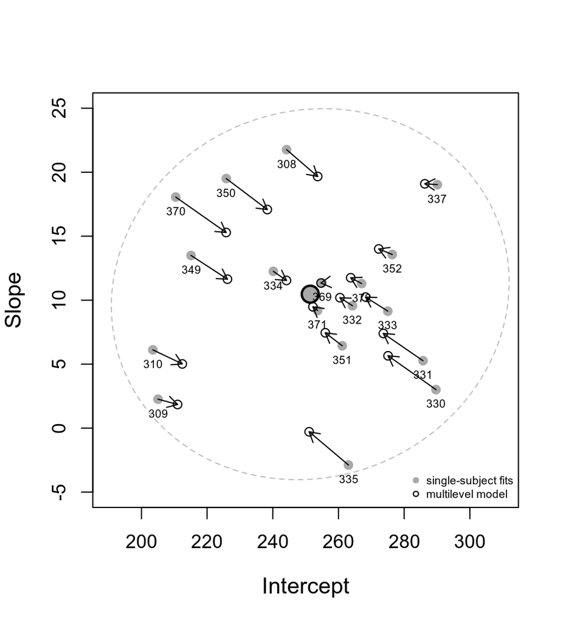

## Diagnostic

As for any linear model, it is important to check that residual errors are well-behaved

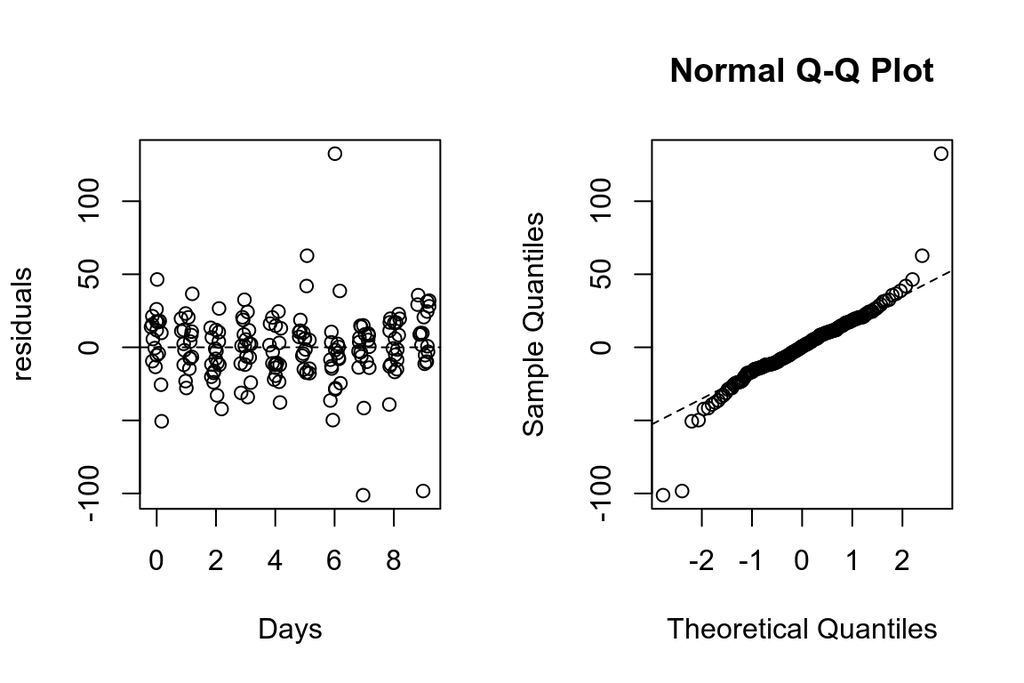

## The *frequentist* approach

- So far, we've seen multilevel models from a **frequentist** point of view.
  - parameters are seen as unknown *fixed* quantities.
  - the goal is to find best guesses (point-estimates) of the parameters.
  - uncertainty in the parameter's value is not treated probabilistically.
  - uncertainty in the estimates is characterized in relation to the data-generating process (think about the highly un-intuitive definition of confidence interval).
  - probability is interpreted as the expected *long-run frequency* of an event in an (imaginary) very large sample.

## The *Bayesian* approach

- What is different in the Bayesian approach?
  - probability is interpreted as the *degree of belief* in the occurrence of an event, or in a proposition.
  - parameters are seen as unknown random variable, uncertainty in their values represented by a *prior* probability distribution.
  - the goal is to update the prior distribution on the basis of the available data, leading to a *posterior* probability distribution.
  - this is done with Bayes' theorem, however the Bayesian approach *is not* distinguished by Bayes' theorem (which is just a trivial implication of probability theory).
  - *"The essential characteristic of Bayesian methods is their explicit use of probability for quantifying uncertainty in inferences based on statistical analysis"* (Gelman et al. 2013).

## Bayesian models

- In a typical Bayesian setting we have a likelihood \(p\left(\text{data} \mid \theta\right)\), conditional on the parameter \(\theta\), and a prior distribution \(p\left(\theta\right)\). The posterior distribution for the parameter is \[ p\left(\theta \mid \text{data}\right) = \frac{p\left(\text{data} \mid \theta\right) p\left(\theta\right)}{p\left( \text{data} \right)} \]

## Bayesian models

- In a typical Bayesian setting we have a likelihood \(p\left(\text{data} \mid \theta\right)\), conditional on the parameter \(\theta\), and a prior distribution \(p\left(\theta\right)\). The posterior distribution for the parameter is \[ p\left(\theta \mid \text{data}\right) = \frac{p\left(\text{data} \mid \theta\right)p\left(\theta\right)}{\int p\left( \text{data} \mid \theta \right) p\left(\theta\right) d\theta}\]

## Bayesian models

- In a typical Bayesian setting we have a likelihood \(p\left(\text{data} \mid \theta\right)\), conditional on the parameter \(\theta\), and a prior distribution \(p\left(\theta\right)\). The posterior distribution for the parameter is \[ p\left(\theta \mid \text{data} \right) = \frac{p\left(\text{data} \mid \theta\right)p\left(\theta\right)}{\int p\left( \text{data} \mid \theta \right) p\left(\theta\right) d\theta}\\ \text{posterior} = \frac{\text{likelihood} \times \text{prior}}{\text{average likelihood}} \]

## Bayesian models

- In a typical Bayesian setting we have a likelihood \(p\left(\text{data} \mid \theta\right)\), conditional on the parameter \(\theta\), and a prior distribution \(p\left(\theta\right)\). The posterior distribution for the parameter is \[ p\left(\theta \mid \text{data}\right) \propto p\left(\text{data} \mid \theta\right)p\left(\theta\right)\\ \text{posterior} \propto \text{likelihood} \times \text{prior} \]

## Bayesian multilevel models

- In the case of a multilevel model, each cluster \(j\) has parameter \(\theta_j\) which is an independent sample from a population distribution governed by some *hyperparameter* \(\phi\).
- \(\phi\) is also not known, and thus has its prior distribution \(p\left(\phi\right)\) (*hyperprior*).
- We have a joint prior distribution: \(p\left(\phi,\theta\right)=p\left(\phi\right) \prod_{j=1}^{J} p\left(\theta_j \mid \phi\right)\)
- and a joint posterior distribution: \[p\left(\phi,\theta \mid \text{data}\right) \propto \underbrace{p\left(\phi\right) \prod_{j=1}^{J} p\left(\theta_j \mid \phi\right)}_\text{prior} \times \underbrace{ p\left(\text{data} \mid \theta_j\right)}_\text{likelihood} \]

## Bayesian parameter inference

- The information we want about a parameter \(\phi\) is contained in its marginal posterior distribution \(p\left(\phi \mid \text{data} \right)=\int p\left(\phi,\theta \mid \text{data} \right) d\theta\).
- The calculation can be difficult once a model has many parameters (to describe the uncertainty in a parameter of interest one must average or *marginalise* over the uncertainty in all other parameters).
- Monte Carlo techniques and computer simulations (Markov-Chain Monte Carlo sampling, MCMC) can be used to draw samples from the posterior distribution.
- Once you have samples from the posterior distribution, summarizing the marginal posterior distribution becomes simply a matter of counting values.

## Metropolis algorithm

Say you want to sample from a density \(P({\bf x})\), but you can only evaluate a function \(f({\bf x})\) that is proportional to the density \(P({\bf x})\):

- Initialization:
  1. choose arbitrary starting point \({\bf x}_0\)
  2. choose a probability density to generate proposals \(g({\bf x}_{n+1}|{\bf x}_n)\) (*proposal density*)
- For each iteration \(i\):
  1. generate a candidate \({\bf x'}\) sampling from \(g({\bf x}_{i+1}|{\bf x}_{i})\)
  2. calculate the *acceptance ratio* \(a = \frac{f({\bf x}')}{f({\bf x}_{i})}\)
  3. *accept/reject*: generate a uniform number \(u\) in \([0,1]\)
     - if \(u \le a\), accept and set \({\bf x}_{i+1}={\bf x'}\) (*"move to the new value"*)
     - if \(u > a\), reject and set \({\bf x}_{i+1}={\bf x}_{i}\) (*"stay where you are"*)

## MCMC example

Let use the sampling algorithm to infer values from one participant of the dataset `sleepstudy`.

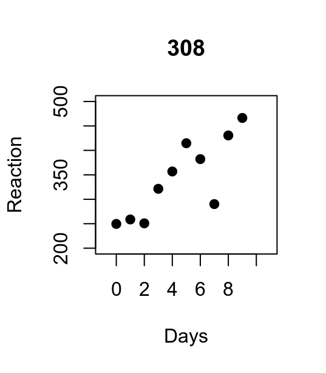

- To sample from the posterior distribution of parameters is sufficient to compute the un-normalized posterior: \(\text{prior} \times \text{likelihood}\)

## MCMC example

First, code one function to compute the (log)likelihood, keeping the data fixed.

```r
x <- sleepstudy$Days[sleepstudy$Subject == "308"]
y <- sleepstudy$Reaction[sleepstudy$Subject == "308"]

loglik <- function(par) {
    # par = [intercept, slope, log(residual Std.)]
    pred <- par[1] + par[2] * x
    return(sum(dnorm(y, mean = pred, sd = exp(par[3]), log = T)))
}
```

## MCMC example

Next, choose your priors

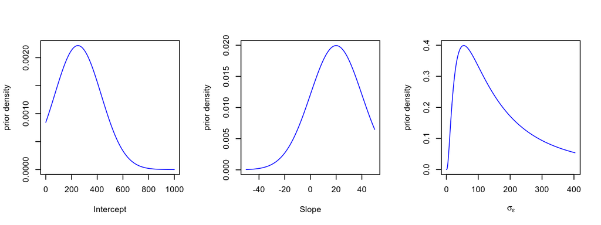

## MCMC example

Next, choose your priors

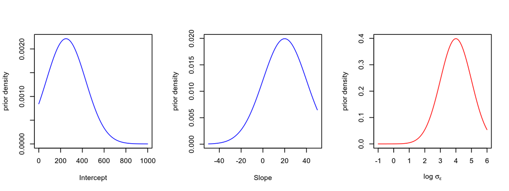

## MCMC example

Write a function that compute the log of the joint prior density for a combination of parameters

```r
logprior <- function(par) {
    intercept_prior <- dnorm(par[1], mean = 250, sd = 180,
        log = T)
    slope_prior <- dnorm(par[2], mean = 20, sd = 20, log = T)
    sd_prior <- dnorm(par[3], mean = 4, sd = 1, log = T)
    return(intercept_prior + slope_prior + sd_prior)
}
```

## MCMC example

Put together likelihood and prior to obtain the (log) posterior density

```r
logposterior <- function(par) {
    return(loglik(par) + logprior(par))
}
```

## MCMC example

Choose the arbitrary starting point and the proposal density \(g({\bf x}_{n+1}|{\bf x}_n)\)

```r
# initial parameters
startvalue <- c(250, 20, 5)

# proposal density
proposalfunction <- function(par) {
    return(rnorm(3, mean = par, sd = c(15, 5, 0.2)))
}
```

## MCMC example

This function execute iteratively the step we have seen before

```r
run_metropolis_MCMC <- function(startvalue, iterations) {
    chain <- array(dim = c(iterations + 1, 3))
    chain[1, ] <- startvalue

    for (i in 1:iterations) {
        # draw a random proposal
        proposal <- proposalfunction(chain[i, ])

        # ratio of posterior density between new and old values
        a <- exp(logposterior(proposal) - logposterior(chain[i,
            ]))

        # accept/reject
        if (runif(1) < a) {
            chain[i + 1, ] <- proposal
        } else {
            chain[i + 1, ] <- chain[i, ]
        }
    }
    return(chain)
}
```

## MCMC example

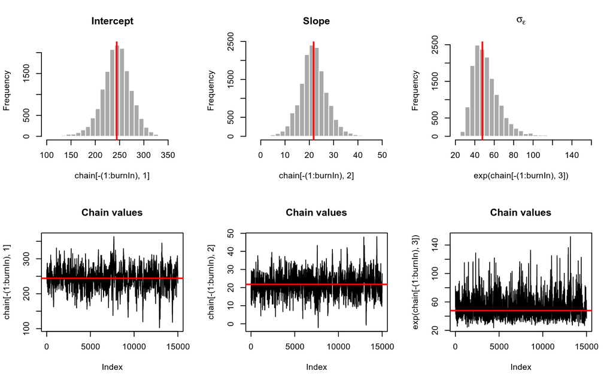

## MCMC example

Having the samples from the posterior distribution, summarising uncertainty is simply a matter of counting values. Here I calculate a 95% Bayesian credible interval for slope.

```r
# remove initial 'burn in' samples
burnIn <- 5000
slope_samples <- chain[-(1:burnIn), 2]

# mean of posterior distribution
mean(slope_samples)
[1] 21.75772

# 95% Bayesian credible interval
alpha <- 0.05
round(c(quantile(slope_samples, probs = alpha/2), quantile(slope_samples,
    probs = 1 - alpha/2)), digits = 2)
 2.5% 97.5%
10.82 33.27
```

- The Metropolis algorithm is the grandparent of modern MCMC techniques for drawing samples from unknown posterior distributions
- Proposals are random and that can make it very inefficient, especially as the complexity of the model (and thus of the posterior) increases
- Modern algorithm use clever proposals to get a better picture of the posterior distribution with fewer samples
- A state-of-the-art algorithm is Hamiltonian Monte Carlo (HMC), which is used by the free software Stan ([mc-stan.org](http://mc-stan.org/))

## Stan

- Stan (named after Stanislaw Ulam, 1909-1984, co-inventor of MCMC methods) is a probabilistic programming language that enabels users to easily Bayesian inference on complex models.
- Once a model is defined, Stan compiles a C++ program that uses HMC to draw samples from the posterior density
- Stan is free, open-source, has a comprehensive documentation and interfaces for the most popular computing environments (R, Matlab, Python, Mathematica)
- We shall see how to build a Bayesian multilevel model in Stan using again the `sleepstudy` dataset
- I will use Stan's R interface (`RStan`, see installation instructions at github.com/stan-dev/rstan/wiki/RStan-Getting-Started)

## Bayesian LMM

- The model can be expressed as \[ y_{j} \sim \text{Normal}\left( \beta_0 + b_{0j} + \left( \beta_1 + b_{1j} \right){\rm{Days}}, \,\, \sigma_{\epsilon}^2 \right)\\ b \sim \text{Normal}\left( 0, \,\, \Omega \right)\\ \]
- Priors\[ \beta_0 \sim \text{Normal} \left(0.3,1 \right)\\ \beta_1 \sim \text{Normal} \left(0.01,0.5 \right)\\ \sigma_{\epsilon} \sim \text{HalfCauchy} \left(0, 0.5\right)\\ \]

## Bayesian LMM

- For efficiency and numerical stability, the matrix \(\Omega\) is usually parametrized by a vector of variances \(\sigma_0, \sigma_1\) and a correlation matrix \(\textbf{R}\) \[ \Omega = \left( \begin{array}{cc} \sigma_0 & 0 \\ 0 & \sigma_1 \end{array} \right) \textbf{R} \left( \begin{array}{cc} \sigma_0 & 0 \\ 0 & \sigma_1 \end{array} \right) \]

## Variance-covariance and correlation matrices

\[ \begin{align*} \Omega & = \left( \begin{array}{cc} \sigma_0 & 0 \\ 0 & \sigma_1 \end{array} \right) \textbf{R} \left( \begin{array}{cc} \sigma_0 & 0 \\ 0 & \sigma_1 \end{array} \right)\\ & = \left( \begin{array}{cc} \sigma_0 & 0 \\ 0 & \sigma_1 \end{array} \right) \left( \begin{array}{cc} 1 & \rho \\ \rho & 1 \end{array} \right) \left( \begin{array}{cc} \sigma_0 & 0 \\ 0 & \sigma_1 \end{array} \right) \\ & = \left( \begin{array}{cc} \sigma_0 & \rho\sigma_0 \\ \rho\sigma_1 & \sigma_1 \end{array} \right) \left( \begin{array}{cc} \sigma_0 & 0 \\ 0 & \sigma_1 \end{array} \right) \\ & = \left( \begin{array}{cc} \sigma_0^2 & \rho\sigma_0\sigma_1 \\ \rho\sigma_0\sigma_1 & \sigma_1^2 \end{array} \right)\\ \end{align*} \]

## Bayesian LMM

- Hyperprior\[ \Omega = \left( \begin{array}{cc} \sigma_0 & 0 \\ 0 & \sigma_1 \end{array} \right) \textbf{R} \left( \begin{array}{cc} \sigma_0 & 0 \\ 0 & \sigma_1 \end{array} \right)\\ {\bf \sigma}_{\Omega} \sim \text{HalfCauchy} \left(0, 0.5\right)\\ \textbf{R} \sim \text{LKJcorr} \left( 2 \right)\\ \]

## Prior for correlation matrix

The LKJ prior (Lewandowski, Kurowicka, & Joe, 2009) is a prior distribution over correlation matrices, has one parameter that control how 'skeptical' is the prior with respect to extreme correlation values.

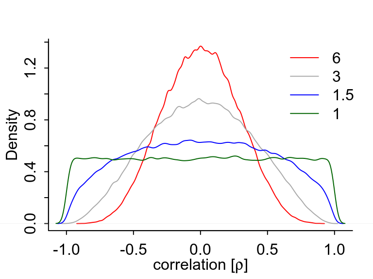

## Coding the model in Stan language

- Stan models are typically specified in separate text files with `.stan` extension
- Model specification consists of several blocks, e.g.
  - `data`: declaration of all dependent/independent variables
  - `parameters`: declare the free parameters of the model
  - `model`: define likelihood function and priors
- Other useful block types:
  - `transformed parameters`: apply any transformation to the parameters, before computing the likelihood
  - `generated quantities`: derive any quantities of interest based on data or parameters

## `data`

```
data {
  int<lower=1> N;                  // number of observations
  real RT[N];                      // reaction time (transformed in seconds)
  int<lower=0,upper=9> Days[N];    // predictor
  int<lower=1> J;                  // number of subjects
  int<lower=1,upper=J> Subject[N]; // subject id
}
```

RStan requires the dataset to be organized as a list object

```r
d_stan <- list(Subject = as.numeric(factor(sleepstudy$Subject,
    labels = 1:length(unique(sleepstudy$Subject)))), Days = sleepstudy$Days,
    RT = sleepstudy$Reaction/1000, N = nrow(sleepstudy),
    J = length(unique(sleepstudy$Subject)))
```

## `parameters`

```
parameters {
  vector[2] beta;               // fixed-effects parameters
  real<lower=0> sigma_e;        // residual std
  vector<lower=0>[2] sigma_u;   // random effects standard deviations
  cholesky_factor_corr[2] L_u;  // L_u is the Choleski factor of the correlation matrix
  matrix[2,J] z_u;              // random effect matrix
}

transformed parameters {
  matrix[2,J] u;
  u = diag_pre_multiply(sigma_u, L_u) * z_u; // use Cholesky to set correlation
}
```

For efficiency and numerical stability (see Stan manual) the correlation matrix \(\textbf{R}\) is parametrized by its Cholesky factor \(\textbf{L}\), which can be seen as the square root of \(\textbf{R}\), i.e. \[\textbf{L}\textbf{L}^T=\textbf{R} = \left( \begin{array}{cc} 1 & \rho \\ \rho & 1 \end{array} \right) \] If \(\textbf{Z}_{\text{uncorr}}\) is a 2x\(n\) matrix where the rows are 2 samples from uncorrelated random variables, then \[ \textbf{Z}_{\text{corr}} = \left( \begin{array}{cc} \sigma_0 & 0 \\ 0 & \sigma_1 \end{array} \right) \textbf{L} \, \textbf{Z}_{\text{uncorr}} \] then \(\textbf{Z}_{\text{corr}}\) have the desired variances \(\sigma_0^2,\sigma_1^2\) and correlation \(\rho\). (\(\textbf{L}\) is lower-triangular Cholesky factor.)

Why does that work? Say the the two uncorrelated samples have zero mean and unit variance, then the covariance matrix is identity matrix, \(\mathbb{E}\left( {Z{Z^T}} \right) - \mathbb{E}\left( Z \right) \mathbb{E}\left(Z \right)^T = \mathbb{E} \left( Z Z^T \right) = I\), and is identical to the correlation matrix.

Say the desired correlation matrix is \(\textbf{R}\); since it is symmetric and positive defined it is possible to obtain the Cholesky factorization \(L{L^T} = \textbf{R}\).

We transform the samples with \(X=LZ\), we have that that the new covariance (correlation) matrix is \[ \begin{align} \mathbb{E} \left(XX^T\right) &= \mathbb{E} \left((LZ)(LZ)^T \right) \\ &= \mathbb{E} \left(LZ Z^T L^T\right) \\ &= L \mathbb{E} \left(ZZ^T \right) L^T \\ &= LIL^T = LL^T = \textbf{R} \\ \end{align} \]

The third step is justified because the expected value is a linear operator, therefore \(\mathbb{E}(cX) = c\mathbb{E}(X)\). Also \((AB)^T = B^T A^T\), the order of the factor reverses.

## `model`

```
model {
  real mu; // conditional mean of the dependent variable

  //priors
  L_u ~ lkj_corr_cholesky(2);   // LKJ prior for the correlation matrix
  to_vector(z_u) ~ normal(0,1); // before Cholesky, random effects are normal variates with SD=1
  sigma_u ~ cauchy(0, 0.5);     // SD of random effects (vectorized)
  sigma_e ~ cauchy(0, 0.5);     // prior for residual standard deviation
  beta[1] ~ normal(0.3, 1);     // prior for fixed-effect intercept
  beta[2] ~ normal(0.01, 0.5);  // prior for fixed-effect slope

  //likelihood
  for (i in 1:N){
    mu = beta[1] + u[1,Subject[i]] + (beta[2] + u[2,Subject[i]])*Days[i];
    RT[i] ~ normal(mu, sigma_e);
  }
}
```

## Running the model

- Run sampling through RStan

```r
library(rstan)

options(mc.cores = parallel::detectCores())  # indicate stan to use multiple cores if available

sleep_model <- stan(file = "sleep_model_v2.stan", data = d_stan,
    iter = 2000, chains = 4)
```

- In case of warnings check 'A brief guide to Stan's warnings' for advice (http://mc-stan.org/misc/warnings.html)

## Evaluating convergence

- Visualize chains to check for convergence

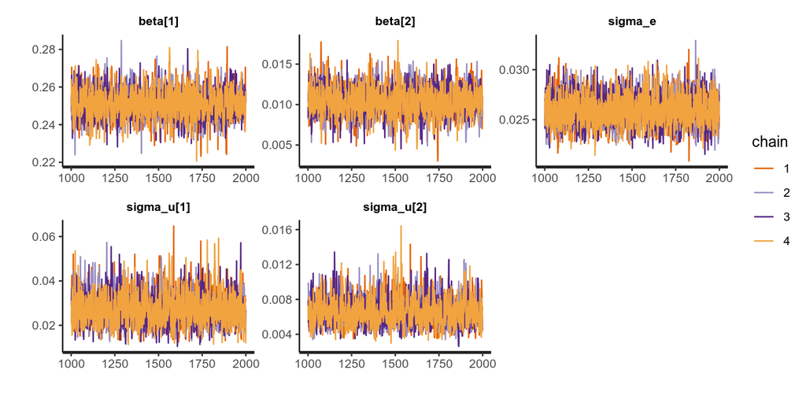

```r
traceplot(sleep_model, pars = c("beta", "sigma_e", "sigma_u"),
    inc_warmup = F)
```

## Evaluating convergence

- Check that \(\hat R \approx 1\pm0.1\) (essentially \(\hat R\) is the ratio of between-chain variance to within-chain variance)

```r
print(sleep_model, pars = c("beta", "sigma_e"), probs = c(0.025,
    0.975), digits = 3)
Inference for Stan model: sleep_model_v2.
4 chains, each with iter=2000; warmup=1000; thin=1;
post-warmup draws per chain=1000, total post-warmup draws=4000.

         mean se_mean    sd  2.5% 97.5% n_eff Rhat
beta[1] 0.251       0 0.008 0.236 0.267  2545    1
beta[2] 0.010       0 0.002 0.007 0.014  2409    1
sigma_e 0.026       0 0.002 0.023 0.029  4000    1

Samples were drawn using NUTS(diag_e) at Sun Sep 23 14:37:56 2018.
For each parameter, n_eff is a crude measure of effective sample size,
and Rhat is the potential scale reduction factor on split chains (at
convergence, Rhat=1).
```

Posterior distribution of fixed-effects parameters.

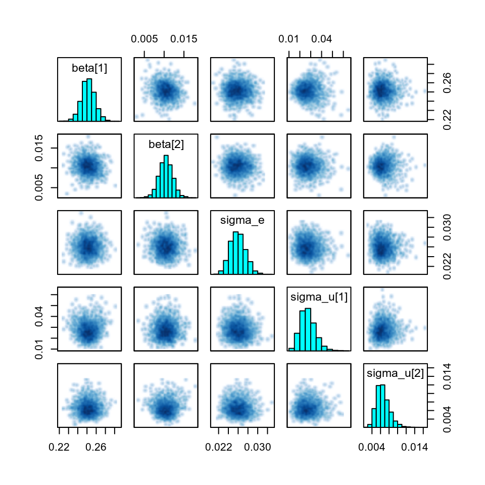

```r
pairs(sleep_model, pars = c("beta", "sigma_e", "sigma_u"))
```

Examine random effects correlation.

```r
# Use the L matrices to compute the correlation matrices
L_u <- extract(sleep_model, pars = "L_u")$L_u
cor_u <- apply(L_u, 1, function(x) tcrossprod(x)[1, 2])
print(signif(quantile(cor_u, probs = c(0.025, 0.5, 0.975))))
      2.5%        50%      97.5%
-0.4676860  0.0597705  0.5986940
```

## Posterior predictive check

- *'simulating replicated data under the fitted model and then comparing these to the observed data'* (Gelman and Hill, 2007).

```
generated quantities {
  real y_rep[N];
  matrix[2,J] u_rep;    // matrix of simulated random effects
    for (j in 1:J) {
    u_rep[1:2,j] = multi_normal_cholesky_rng(rep_vector(0, 2),
                                    diag_matrix(sigma_u) * (L_u));
  }
  for (i in 1:N){     // simulate the model
    y_rep[i] = normal_rng(beta[1] + u_rep[1,Subject[i]] +
                          (beta[2] + u_rep[2,Subject[i]])*Days[i],
                          sigma_e);
  }
}
```

## Posterior predictive check

- If the model fits, then replicated data generated under the model should look similar to observed data.
- Generating random observations from new simulated observers allow approximating the *posterior predictive distribution*, \(p \left( y^{\text{rep}} \mid y \right) = \int p \left( y^{\text{rep}} \mid \theta \right) p\left(\theta \mid y\right) d \theta\)

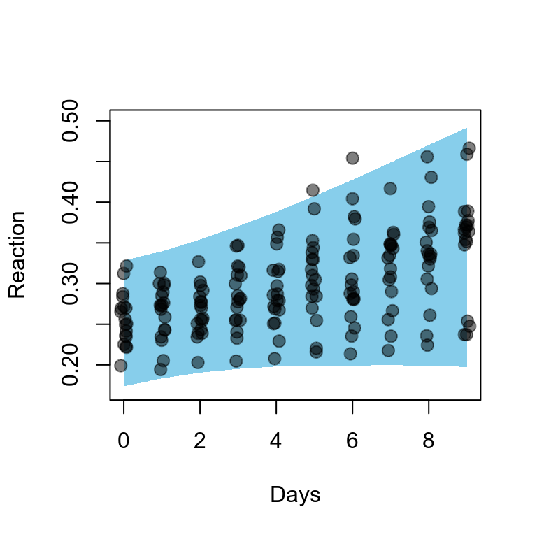

Comparison with `lme4` random effects estimates.

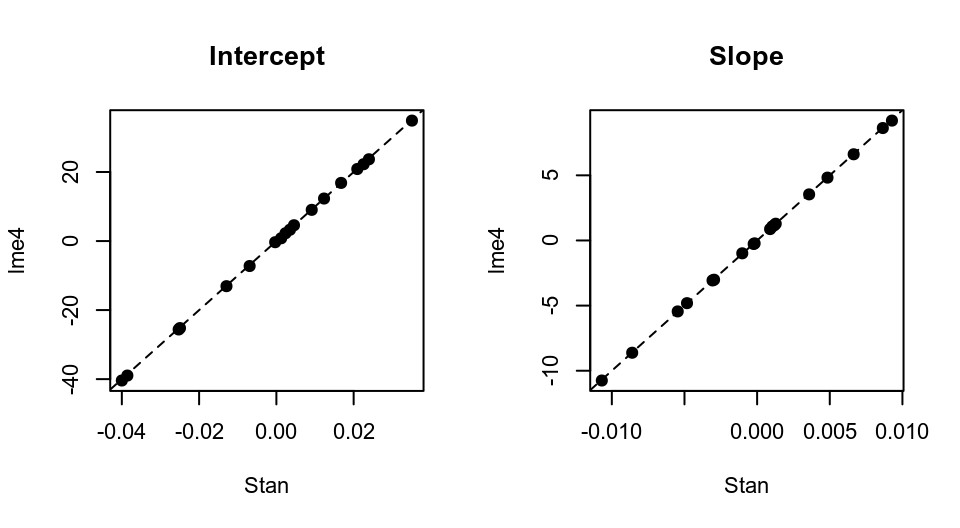

```r
# extract samples
samples_rf0 <- extract(sleep_model, pars = "u")$u[, 1, ]
samples_rf1 <- extract(sleep_model, pars = "u")$u[, 2, ]

# compute posterior mean
rf_int <- apply(samples_rf0, 2, mean)
rf_slp <- apply(samples_rf1, 2, mean)

par(mfrow = c(1, 2))  # plot
plot(rf_int, ranef(m.1)$Subject[, 1], pch = 19, xlab = "Stan",
    ylab = "lme4", main = "Intercept")
plot(rf_slp, ranef(m.1)$Subject[, 2], pch = 19, xlab = "Stan",
    ylab = "lme4", main = "Slope")
```

## `rstanarm`

- It is not strictly necessary to write code from scratch in case of standard models
- The package `rstanarm` automatically prepare Stan code from a model specified in standard R syntax, e.g.

```r
library(rstanarm)
sleepstudy$Reaction_s <- sleepstudy$Reaction/1000

sleep_model_2 <- stan_lmer(Reaction_s ~ Days + (Days | Subject),
    data = sleepstudy, cores = 2, iter = 2000, chain = 4)
```

## `rstanarm`

- Priors can be assigned (see the function `prior_summary()` to examine the default)
- Another options is the package `bmrs` (Bürkner, 2017)

```r
summary(sleep_model_2, pars = c("(Intercept)", "Days"),
    digits = 3)

Model Info:

 function:     stan_lmer
 family:       gaussian [identity]
 formula:      Reaction_s ~ Days + (Days | Subject)
 algorithm:    sampling
 priors:       see help('prior_summary')
 sample:       4000 (posterior sample size)
 observations: 180
 groups:       Subject (18)

Estimates:
              mean   sd    2.5%   25%   50%   75%   97.5%
(Intercept) 0.251  0.007 0.237  0.247 0.251 0.256 0.265
Days        0.010  0.002 0.007  0.009 0.010 0.011 0.014

Diagnostics:
            mcse  Rhat  n_eff
(Intercept) 0.000 1.000 1790
Days        0.000 1.004 1364

For each parameter, mcse is Monte Carlo standard error, n_eff is a crude measure of effective sample size, and Rhat is the potential scale reduction factor on split chains (at convergence Rhat=1).
```

## Interim summary

- Multilevel model are characterised by more than one sources of "random" variation
- The distinguishing feature of Bayesian methods is the explicit use of probability distributions to quantify the uncertainty about unknown quantities
- Using samples to approximate posterior distributions makes it much easier to summarize the results
- Bayesian models estimated by MCMC sampling do not have the problem of convergence warnings (as in `lme4`), but it is important to check that sampling was succesfull (e.g. \(\hat R\), …)

## MCMC: taming a wild chain

- When the posterior density has broad, flat regions, chains can wander erratically

```r
dat <- list(y = c(-1, 1))
stan_code <- "
data{
  real y[2];
}
parameters{
  real mu;
  real<lower=0> sigma;
}
model{
  y ~ normal(mu, sigma);
}
"
m_ <- stan(model_code = stan_code, data = dat, iter = 2000,
    chains = 4)
```

## MCMC: taming a wild chain

- When the posterior density has broad, flat regions, chains can wander erratically

[figure not shown]

```r
rstan::traceplot(m_, pars = c("mu", "sigma"), inc_warmup = F)
```

## MCMC: taming a wild chain

- Weakly informative prior can gently guide the Markov chain toward reasonable parameter values

```r
dat <- list(y = c(-1, 1))
stan_code <- "
data{
  real y[2];
}
parameters{
  real mu;
  real<lower=0> sigma;
}
model{
  mu ~ normal(1, 10);
  sigma ~ cauchy(0, 1);
  y ~ normal(mu, sigma);
}
"
m_ <- stan(model_code = stan_code, data = dat, iter = 2000,
    chains = 4)
```

## MCMC: taming a wild chain

- Weakly informative prior can gently guide the Markov chain toward reasonable parameter values

[figure not shown]

```r
rstan::traceplot(m_, pars = c("mu", "sigma"), inc_warmup = F)
```

## MCMC: non-identifiable parameters

- Markow chains give problems if parameters are non-identifiable (e.g. highly correlated predictors)

```r
dat <- list(y = rnorm(100, mean = 0, sd = 1))
stan_code <- "
data{
  real y[100];
}
parameters{
  vector[2] alpha;
  real<lower=0> sigma;
}
model{
  real mu;
  mu = alpha[1] + alpha[2];
  y ~ normal(mu, sigma);
}
"
m_ <- stan(model_code = stan_code, data = dat, iter = 4000,
    chains = 2)
```

## MCMC: non-identifiable parameters

- Markow chains give problems if parameters are non-identifiable (e.g. highly correlated predictors)

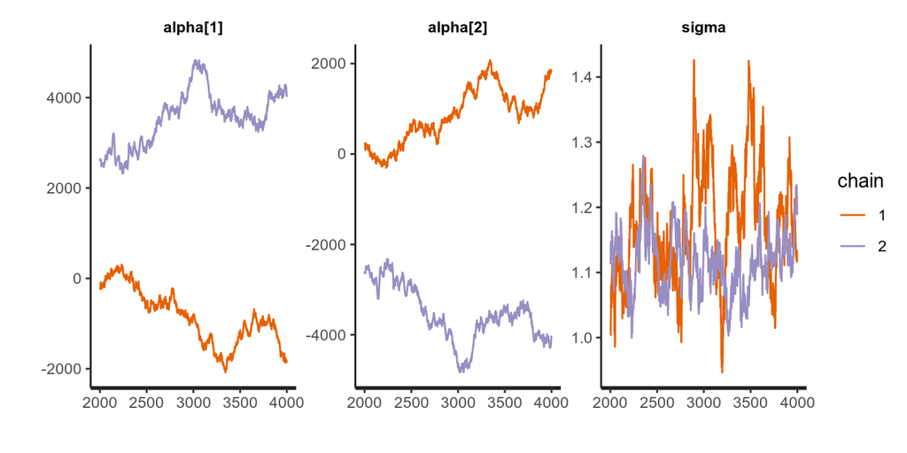

```r
rstan::traceplot(m_, pars = c("alpha", "sigma"), inc_warmup = F)
```

## MCMC: non-identifiable parameters

- Weakly informative priors can help also in this case

```r
dat <- list(y = rnorm(100, mean = 0, sd = 1))
stan_code <- "
data{
  real y[100];
}
parameters{
  vector[2] alpha;
  real<lower=0> sigma;
}
model{
  real mu;
  alpha ~ normal(0, 10);
  mu = alpha[1] + alpha[2];
  y ~ normal(mu, sigma);
}
"
m_ <- stan(model_code = stan_code, data = dat, iter = 4000,
    chains = 2)
```

## MCMC: non-identifiable parameters

- Weakly informative priors can help also in this case.

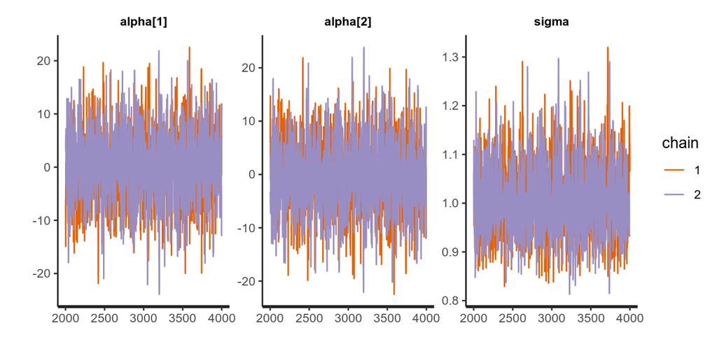

```r
rstan::traceplot(m_, pars = c("alpha", "sigma"), inc_warmup = F)
```

## Priors

- Priors are the initial belief about the plausiblity of possible parameter values.
- There are no *conventional* priors (differently from likelihoods).
- Priors are subjective, but explicitly stated and easily criticized (e.g. less opaque than dropping outliers).
- Priors are assumptions, and should be criticized (e.g. try different assumptions to check how sensitive inference is to the choice of priors).
- Priors cannot be exact, but should be defendable.

## Priors

- There are no non-informative priors: *flat* priors such as \(\text{Uniform} \left(- \infty, \infty \right)\) tells the model that unrealistic values (e.g. extremely large) are as plausible as realistic ones.
- Priors should restrict parameter space to values that make sense.
- Preferably choose *weakly informative* priors that convey less information than you have available.
- Priors should provide some regularization, i.e. endow the model with some skepticism, so that it doesn't get too excited when learning from the data (in a frequentist settings, this is similar to *penalized likelihood* methods)
- Prior recommendations: https://github.com/stan-dev/stan/wiki/Prior-Choice-Recommendations
- If using informative priors, these should be justified in the text when reporting the results (see examples in Gelman & Hennig, 2016, *Beyond subjective and objective in statistics*)

## Generalized linear models (GLM)

- A generalization of linear models where the linear predictor is related to the dependent variable through a *link function* \[ \Phi^{-1} \left[ p \left(y=1 \right) \right] = \textbf{X} \beta \]
- The coefficients of the GLM can be straighforwardly mapped to the parameters of the psychometric function \[ \begin{align} p \left(y_i\right) & = \Phi\left(\frac{x_i -\mu}{\sigma} \right) \\ & = \Phi ( -\frac{\mu}{\sigma} + \frac{1}{\sigma}x_i )\\ & = \Phi\left(\beta_0 + \beta_1x_i \right) \\ \\& \mu=-\frac{\beta_0}{\beta_1}, \,\,\, \sigma=\frac{1}{\beta_1} \\ \end{align} \]

## Generalized linear multilevel models

- Often psychometric function are fit to individual data and group analysis is done on the estimated parameters. This approach neglects subject-specific standard errors and imbalances in the number of repetitions/trials.
- Inferences can be improved by adopting a (generalized linear) multilevel approach (GLMM) \[ p \left(y \mid b\right) = \Phi \left( \textbf{X} \beta + \textbf{Z} b \right) \\ b \sim \mathcal{N}\left( 0, \Omega \right) \]
- This model could be estimated with the `glmer` function of the `lme4` library. However it is not a realistic model: sometimes subjects push buttons at random and make stimulus-independent errors (lapses)
- We can extend this model with an extra parameter \(\lambda\) indicating the probability of lapsing\[ p \left(y \mid b\right) = \lambda+\left( 1-2\lambda \right) \times \Phi \left( \textbf{X} \beta + \textbf{Z} b \right) \\ b \sim \mathcal{N}\left( 0, \Omega \right)\\ \]

## GLMM example

- Observer were presented with two brief (250ms) peripheral stimuli, and asked to indicate which of the two was the furthest from the central fixation point.
- 2 conditions, with different levels of blur of the targets. How does the precision of position judgments change across conditions?

```r
d <- read.table("bisection2.txt", sep = "\t", header = T)
str(d)
'data.frame':   4593 obs. of  5 variables:
 $ id  : int  4 4 4 4 4 4 4 4 4 4 ...
 $ dx  : num  0.04 -0.04 -0.53 -0.53 -0.36 0.44 0.53 0.69 0.93 -1.09 ...
 $ rr  : int  1 1 0 1 0 1 0 1 0 0 ...
 $ acc : int  1 0 1 0 1 1 0 1 0 1 ...
 $ cond: int  1 2 1 2 2 1 2 2 2 2 ...
```

## GLMM example

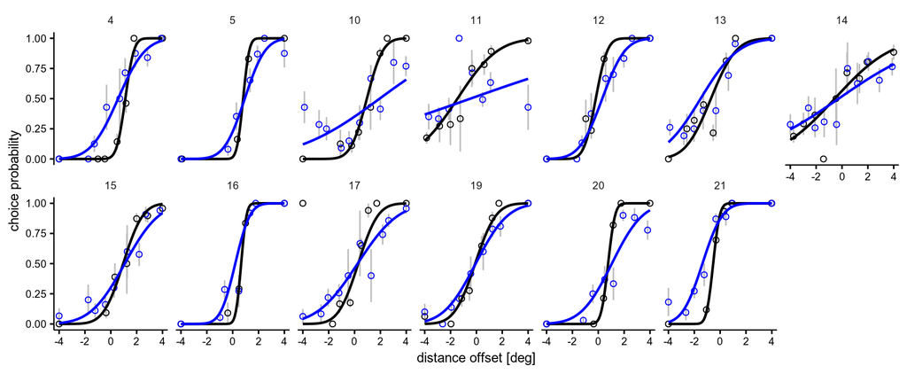

## Lapse rates

- Each observer \(j\) has a specific lapse rate \(\lambda_j\). We use a Beta distribution to express the distribution of lapse rates in the population\[ \lambda_j \sim \text{Beta} \left(a,b\right) \]

## Lapse rates

- Each observer \(j\) has a specific lapse rate \(\lambda_j\). We use a Beta distribution to express the distribution of lapse rates in the population\[ \lambda_j \sim \text{Beta} \left(a,b\right) \]

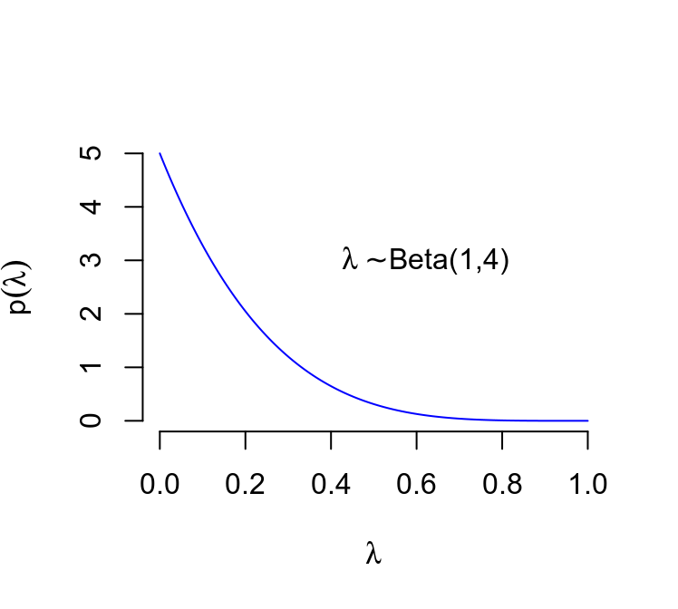

- \(a\) and \(b\) are the *hyperparameter* that govern the distribution of lapse rates in the population. We need an *hyperprior* to express the uncertainty in their values.
- Since \(a>0\) and \(b>0\), the hyperprior can be modelled with a Gamma distribution. We can set the shape and rate parameters of the Gamma so that they favor a positively skewed Beta distribution with mode at 0\[ a \sim \text{Gamma} \left(4,1 \right)\\ b \sim \text{Gamma} \left(1,0.2 \right)\\ \]

[figure not shown]

## Stan code

Declare all the variables in the `data` block.

```
data {
  int<lower=1> N;
  int<lower=0,upper=1> rr[N];
  real ds[N];
  int<lower=0,upper=1> cond[N];
  int<lower=1> J;
  int<lower=1,upper=J> id[N];
}
```

Define the free parameters in the `parameters` block

```
parameters {
  vector[4] beta;                    // fixed-effects parameters
  vector<lower=0,upper=1>[J] lambda; // lapse rate
  vector<lower=0>[2] beta_ab;        // population parameters of lapse rate
  vector<lower=0>[4] sigma_u;        // random effects standard deviations
  cholesky_factor_corr[4] L_u;       // L_u is the Choleski factor of the correlation matrix
  matrix[4,J] z_u;                   // random effect matrix
}
```

In the `transformed parameters` block apply any transformations needed to compute the likelihood.

```
transformed parameters {
  matrix[4,J] u;
  u = diag_pre_multiply(sigma_u, L_u) * z_u; // use Cholesky to set correlation
}
```

Define priors and likelihood in the `model` block.

```
model {
  real mu; // linear predictor

  //priors
  L_u ~ lkj_corr_cholesky(2);   // LKJ prior for the correlation matrix
  to_vector(z_u) ~ normal(0,1); // before Cholesky, random eff. are normal variates with SD=1
  sigma_u ~ cauchy(0, 1);       // SD of random effects (vectorized)
  beta[1] ~ normal(0, 2);       // prior for intercept (cond 1)
  beta[2] ~ normal(0, 4);       // prior for slope (cond 1)
  beta[3] ~ normal(0, 1);       // prior for diff. in intercept (cond 1)
  beta[4] ~ normal(0, 2);       // prior for diff. in slope (cond 1)
  beta_ab[1] ~ gamma(4,1);      // hyper priors for lapse rate distribution
  beta_ab[2] ~ gamma(1,0.2);
  lambda ~ beta(beta_ab[1] ,beta_ab[2]);  //lapse rate

  //likelihood
  for (i in 1:N){
    mu = beta[1] + u[1,id[i]] + cond[i]*(beta[2]+u[2,id[i]])
        + (beta[3] + u[3,id[i]] + cond[i]*(beta[4] + u[4,id[i]] ))*ds[i];
    rr[i] ~ bernoulli((1-lambda[id[i]])*Phi(mu)+lambda[id[i]]/2);
  }
}
```

Prepare the data as a list for Stan.

```r
d_stan <- list(id = as.numeric(factor(d$id, labels = 1:length(unique(d$id)))),
    ds = d$dx, rr = d$rr, N = nrow(d), J = length(unique(d$id)),
    cond = d$cond - 1)
str(d_stan)
List of 6
 $ id  : num [1:4593] 1 1 1 1 1 1 1 1 1 1 ...
 $ ds  : num [1:4593] 0.04 -0.04 -0.53 -0.53 -0.36 0.44 0.53 0.69 0.93 -1.09 ...
 $ rr  : int [1:4593] 1 1 0 1 0 1 0 1 0 0 ...
 $ N   : int 4593
 $ J   : int 13
 $ cond: num [1:4593] 0 1 0 1 1 0 1 1 1 1 ...
```

Run sampling

```r
bisection_model <- stan(file = "bisection_stan_v1.stan",
    data = d_stan, iter = 4000, chains = 4)
```

Check the convergence by visualising the chains

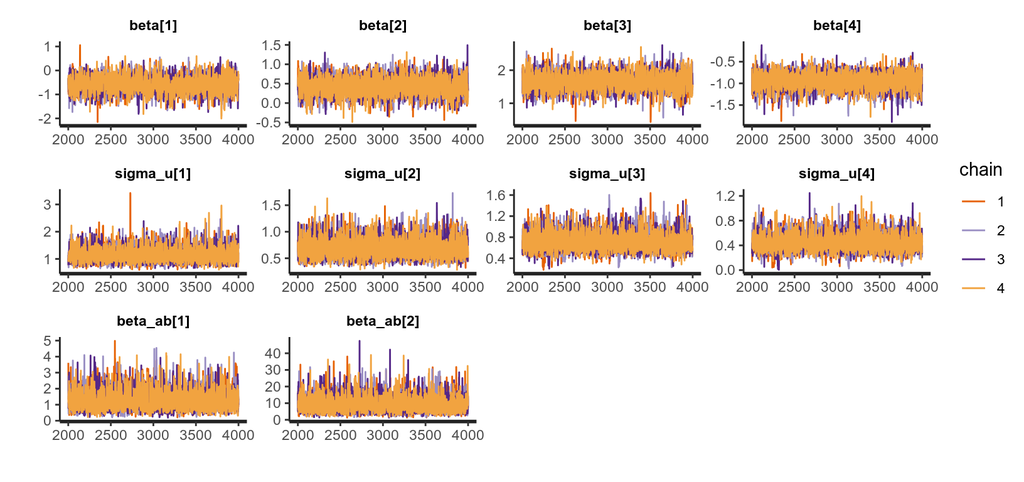

```r
traceplot(bisection_model, pars = c("beta", "sigma_u", "beta_ab"),
    inc_warmup = F)
```

Visualize posterior distribution

[figure not shown]

```r
pairs(bisection_model, pars = c("beta", "sigma_u"))
```

[figure not shown]

```r
print(bisection_model, pars = c("beta", "sigma_u", "beta_ab"),
    probs = c(0.025, 0.975), digits = 3)
Inference for Stan model: bisection_stan_v1.
4 chains, each with iter=4000; warmup=2000; thin=1;
post-warmup draws per chain=2000, total post-warmup draws=8000.

             mean se_mean    sd   2.5%  97.5% n_eff  Rhat
beta[1]    -0.577   0.007 0.329 -1.231  0.068  2512 1.001
beta[2]     0.430   0.004 0.216  0.001  0.865  3396 1.001
beta[3]     1.661   0.005 0.247  1.194  2.156  2596 1.000
beta[4]    -0.946   0.003 0.177 -1.312 -0.625  2926 1.000
sigma_u[1]  1.152   0.004 0.251  0.767  1.725  3708 1.000
sigma_u[2]  0.689   0.003 0.168  0.421  1.081  4004 1.000
sigma_u[3]  0.705   0.003 0.170  0.434  1.099  2604 1.001
sigma_u[4]  0.440   0.003 0.132  0.214  0.740  2404 1.001
beta_ab[1]  1.233   0.011 0.567  0.435  2.594  2458 1.000
beta_ab[2]  9.303   0.082 4.554  3.029 20.679  3110 1.000

Samples were drawn using NUTS(diag_e) at Thu Sep 27 09:44:39 2018.
For each parameter, n_eff is a crude measure of effective sample size,
and Rhat is the potential scale reduction factor on split chains (at
convergence, Rhat=1).
```

## Inference

Dedicated packages (e.g. the package `bayesplot`) makes it easier to summarize the results.

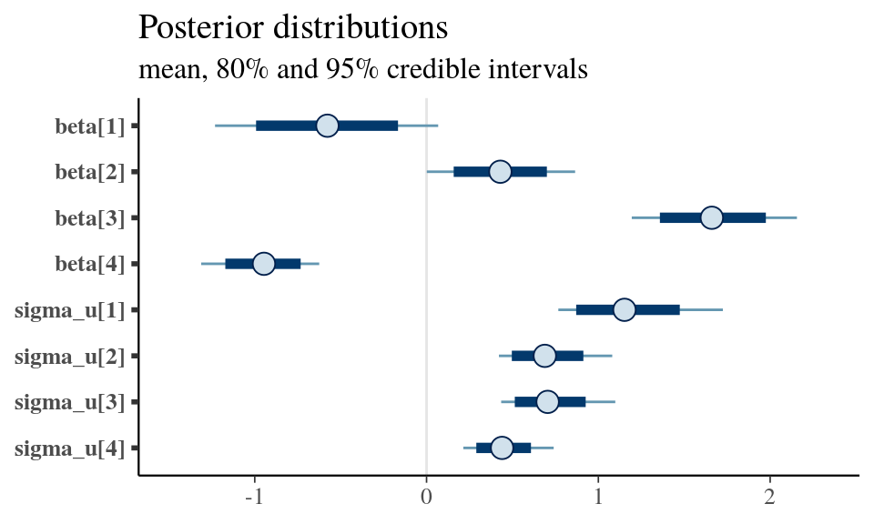

```r
library(bayesplot)
posterior2 <- extract(bisection_model)
mcmc_intervals(posterior2, regex_pars = c("beta\\[[1-4]",
    "sigma_u\\[[1-4]"), prob = 0.8, prob_outer = 0.95, point_est = "mean")
```

## Inference

Dedicated packages (e.g. the package `bayesplot`) makes it easier to summarize the results.

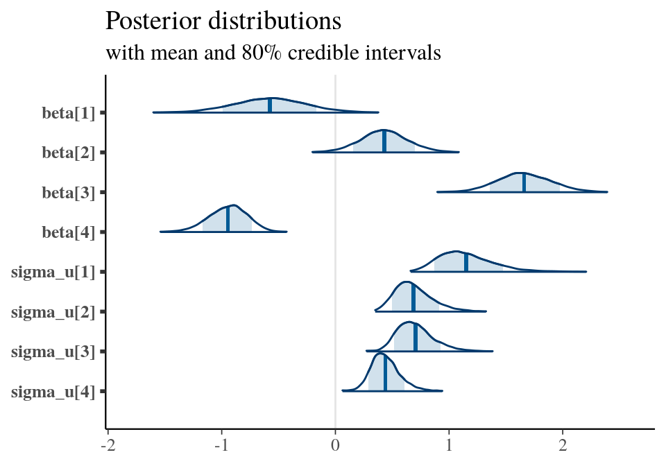

```r
mcmc_areas(posterior2, regex_pars = c("beta\\[[1-4]", "sigma_u\\[[1-4]"),
    prob = 0.8, point_est = "mean")
```

## Inference

Fixed-effects are parametrised according to standard GLM formulation (in terms of \(\beta_0, \beta_1, \dots\)). These can be easily transformed in the psychometric functions parameters \(\mu\) and \(\sigma\).

```r
beta_par <- extract(bisection_model, pars = "beta")$beta
jnd_1 <- 1/beta_par[, 3]
jnd_2 <- 1/(beta_par[, 3] + beta_par[, 4])
jnd_diff <- jnd_2 - jnd_1  # posterior JND differences distribution
```

Calculate Highest Posterior Density (HPD) intervals (the narrowest interval containing the specified probability mass, e.g. 0.95).

```r
jnd_ci_1 <- HPDinterval(as.mcmc(jnd_1), prob = 0.95)
jnd_ci_2 <- HPDinterval(as.mcmc(jnd_2), prob = 0.95)
jnd_ci_diff <- HPDinterval(as.mcmc(jnd_diff), prob = 0.95)
```

## Inference

Plot

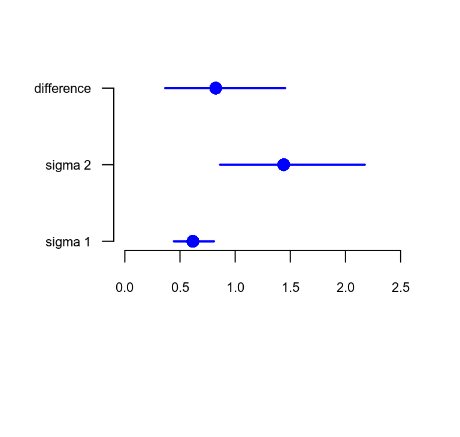

```r
Hmisc::errbar(c("sigma 1", "sigma 2", "difference"), c(mean(jnd_1),
    mean(jnd_2), mean(jnd_diff)), yplus = c(jnd_ci_1[2],
    jnd_ci_2[2], jnd_ci_diff[2]), yminus = c(jnd_ci_1[1],
    jnd_ci_2[1], jnd_ci_diff[1]))
```

## Hierarchical mixtures

- Participants adjust an arrow to report the direction of a briefly presented moving stimulus, in one of two conditions, pre vs. post cue (data from Haladjian, Lisi & Cavanagh, APP 2018).
- We are interested in both the variability and the bias of the response error.
- These measures can be distorted by random guesses, so they are tipycally modelled as a mixture of a uniform and a bell-shaped distribution (e.g. Gaussian, vonMises).
- Here, the response are angles, and the response error is bounded within \(-\pi\) and \(\pi\)
- The mixture model can be expressed as \[ p(x)=\lambda \frac{1}{2\pi} + (1-\lambda) \frac{1}{2\pi I_0(k)} e^{k \cos (x-\mu)} \] where \(\lambda\) indicates the probability of a random response.

## Hierarchical mixtures

```r
d <- read.table("cueingdd.txt", header = T, sep = "\t")
d$alpha_rad <- d$alpha_deg/180 * pi
d$rerr <- d$dir * angDiff(d$alpha_rad, d$resp)  # transform in signed angular differences
str(d)
'data.frame':   4608 obs. of  8 variables:
 $ id       : Factor w/ 8 levels "sj01","sj02",..: 1 1 1 1 1 1 1 1 1 1 ...
 $ cue      : int  2 2 2 2 2 1 2 2 2 2 ...
 $ alpha_deg: int  220 270 130 180 320 50 330 90 300 80 ...
 $ location : int  2 4 2 2 3 4 1 4 1 3 ...
 $ dir      : int  1 -1 1 1 1 1 1 1 -1 1 ...
 $ resp     : num  -1.77 -0.35 1.84 -2.12 -0.38 1.22 0.37 1.57 -1.96 1.87 ...
 $ rerr     : num  0.673 -1.221 -0.429 1.022 0.318 ...
 $ alpha_rad: num  3.84 4.71 2.27 3.14 5.59 ...
```

## Hierarchical mixtures

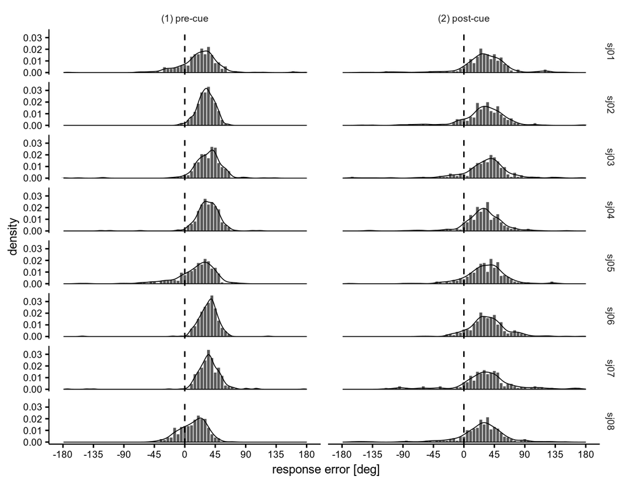

## Hierarchical mixtures

- `data` block.

```
data {
  int<lower=1> N;
  real<lower=-pi(),upper=pi()> rerr[N];
  int<lower=1,upper=2> cue[N];
  int<lower=1> J;
  int<lower=1,upper=J> id[N];
}
```

## Hierarchical mixtures

- `parameter` block.

```
parameters {
  // group-level
  vector[2] mu;         // bias
  vector[2] logk;       // k (log scale)
  vector[2] logilambda;   // mixing parameter (probit scale)

  // subject specific
  vector<lower=0>[6] sigma_u;    // random effects standard deviations
  cholesky_factor_corr[6] L_u;   // L_u is the Choleski factor
  matrix[6,J] z_u;               // random effect matrix
}
```

## Hierarchical mixtures

```
transformed parameters {
  matrix<lower=0,upper=1>[2,J] lambda_j;
  matrix<lower=0>[2,J] kappa_j;
  matrix[2,J] mu_j;
  matrix[6,J] u;

  u = diag_pre_multiply(sigma_u, L_u) * z_u;

  for (j in 1:J){
    mu_j[1,j]= mu[1] + u[1,j];
    mu_j[2,j]= mu[2] + u[2,j];
    kappa_j[1,j]= exp(logk[1] + u[3,j]);
    kappa_j[2,j]= exp(logk[2] + u[4,j]);
    lambda_j[1,j]= inv_logit(logilambda[1] + u[5,j]);
    lambda_j[2,j]= inv_logit(logilambda[2] + u[6,j]);
  }
}
```

## Hierarchical mixtures

- `model` block.

```
model {
  // priors
  L_u ~ lkj_corr_cholesky(2);
  to_vector(z_u) ~ normal(0,1);
  sigma_u ~ normal(0, 10);
  mu ~ normal(0.5, 10);
  logk ~ normal(2, 20);
  logilambda ~ normal(-4, 30);

  // likelihood
  for (n in 1:N){
    if (kappa_j[cue[n],id[n]] < 100)
      target += log_mix(lambda_j[cue[n],id[n]],
                      uniform_lpdf(rerr[n] | -pi(), pi()),
                      von_mises_lpdf(rerr[n] | mu_j[cue[n],id[n]], kappa_j[cue[n],id[n]]));
    else
      target += log_mix(lambda_j[cue[n],id[n]],
                      uniform_lpdf(rerr[n] | -pi(), pi()),
                      normal_lpdf(rerr[n] | mu_j[cue[n],id[n]], sqrt(1/kappa_j[cue[n],id[n]])));
  }
}
```

## Hierarchical mixture

- Check convergence across chains.

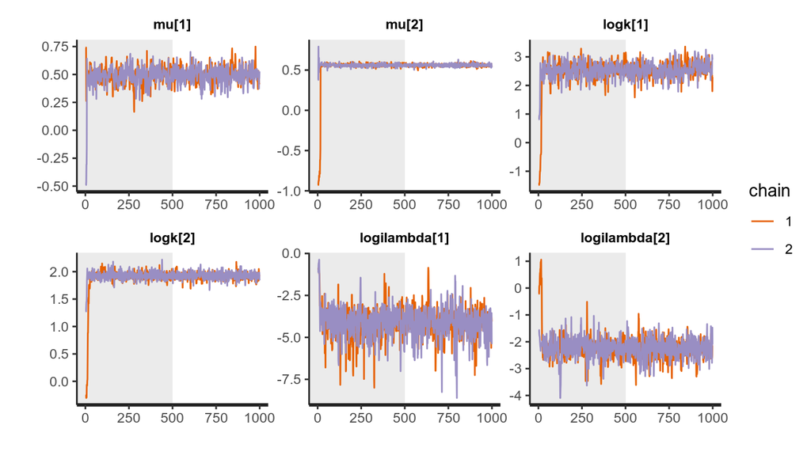

## Hierarchical mixture

- Compute Bayesian credibility interval over mean bias differences.

```r
mu1 <- extract(mix_model, pars = "mu[1]", inc_warmup = F,
    permuted = FALSE)
mu2 <- extract(mix_model, pars = "mu[2]", inc_warmup = F,
    permuted = FALSE)
mu1 <- c(mu1[, 1, 1], mu1[, 2, 1])/pi * 180
mu2 <- c(mu2[, 1, 1], mu2[, 2, 1])/pi * 180

HPDinterval(as.mcmc(mu2 - mu1), prob = 0.95)
         lower    upper
var1 -2.806921 12.10085
attr(,"Probability")
[1] 0.95
```

## Hierarchical mixture

- Compute Bayesian credibility interval over mean differences in precision.

```r
k1 <- extract(mix_model, pars = "logk[1]", inc_warmup = F,
    permuted = FALSE)
k2 <- extract(mix_model, pars = "logk[2]", inc_warmup = F,
    permuted = FALSE)

# transform concentration parameter k into a standard
# deviation
k2SD <- function(k) sqrt(-2 * log(besselI(k, nu = 1)/besselI(k,
    nu = 0)))

sd1 <- k2SD(exp(c(k1[, 1, 1], k1[, 2, 1])))/pi * 180
sd2 <- k2SD(exp(c(k2[, 1, 1], k2[, 2, 1])))/pi * 180

HPDinterval(as.mcmc((sd2 - sd1), prob = 0.95))
       lower    upper
var1 1.98266 10.74307
attr(,"Probability")
[1] 0.95
```

## Useful resources

- Stan User manual.
- Stan forum: https://discourse.mc-stan.org.
- *Statistical Rethinking: A Bayesian Course with Examples in R and Stan*, Richard McElreath CRC Press, 2015.